# Bayesian Data analysis

yingying

November 21, 2018

## Why Bayesian?

The great benefit with Bayesian inference is that it is a principled and coherent framework with to produce inferences that have a (relatively) straight forward interpretation (it’s all probability). Furthermore, once you’ve got the Bayesian machinery going you have great flexibility when it comes to modeling your data. Bayesian statistics is more like Lego, once you learn how to stick the blocks together the sky is the limit.

Instead of probing the question whether the mean difference between two groups is zero or not Bayesian inference does parameter estimation, effectively probing how large a difference there is. The question of how large or how much is often the more sensible question to ask. Parameter estimation is what you really want to do most of the time rather that hypothesis testing.

See paper [Bayesian Estimation Supersedes the T-test](http://www.indiana.edu/~kruschke/BEST/BEST.pdf)

## Introduction to a magic package

Bayesian First Aid is an R package that implements Bayesian alternatives to the most commonly used statistical tests. The package aims at being as easy as possible to pick up and use, especially if you are already used to the classical .test functions. The main gimmick is that the Bayesian alternatives will have the same calling semantics as the corresponding classical test functions save for the addition of bayes. to the beginning of the function name.

```r
# install package
# devtools::install_github("rasmusab/bayesian_first_aid")
library(BayesianFirstAid)
library(dplyr)
library(ggplot2)
```

## Bayesian alternative to t test

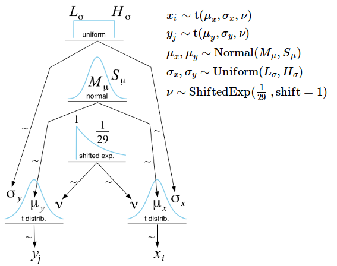

model

It assumes the data (x) is distributed as a t distribution which is more robust than a normal distribution due to its wider tails. Except for the mean (μ) and the scale (σ) the t has one additional parameter, the degree-of-freedoms (ν), where the lower ν is the wider the tails become. When ν gets larger the t distribution approaches the normal distribution.

The prior on ν is an exponential distribution with mean 29 shifted 1 to the right keeping ν away from zero. From the [paper](http://www.indiana.edu/~kruschke/BEST/BEST.pdf): “This prior was selected because it balances nearly normal distributions (ν > 30) with heavy tailed distributions (ν < 30)”. The priors on μ and σ are decided by the hyper parameters Mμ, Sμ, Lσ and Hσ. By taking a peek at the data these parameters are set so that the resulting priors are extremely wide.

Here we instead assume the two groups share a common ν resulting in a model with five parameters: μx,μy,σx,σy and v

```r
# read data
df <- read.csv(url("http://sumsar.net/files/posts/2014-02-04-bayesian-first-aid-one-sample-t-test/roubik_2002_coffe_yield.csv"))
df$diff<- df$yield_81_to_01 - df$yield_61_to_80
yield_diff_new <- with(df[df$world == "new", ], yield_81_to_01 - yield_61_to_80)
yield_diff_old <- with(df[df$world == "old", ], yield_81_to_01 - yield_61_to_80)
```

[figure not shown]

```r
bayes.t.test(yield_diff_new, yield_diff_old)
```

```
##
##  Bayesian estimation supersedes the t test (BEST) - two sample
##
## data: yield_diff_new (n = 13) and yield_diff_old (n = 15)
##
##   Estimates [95% credible interval]
## mean of yield_diff_new: 1376 [334, 2435]
## mean of yield_diff_old: 715 [-1278, 2792]
## difference of the means: 644 [-1635, 2937]
## sd of yield_diff_new: 1625 [795, 2656]
## sd of yield_diff_old: 3556 [1317, 5840]
##
## The difference of the means is greater than 0 by a probability of 0.726
## and less than 0 by a probability of 0.274
```

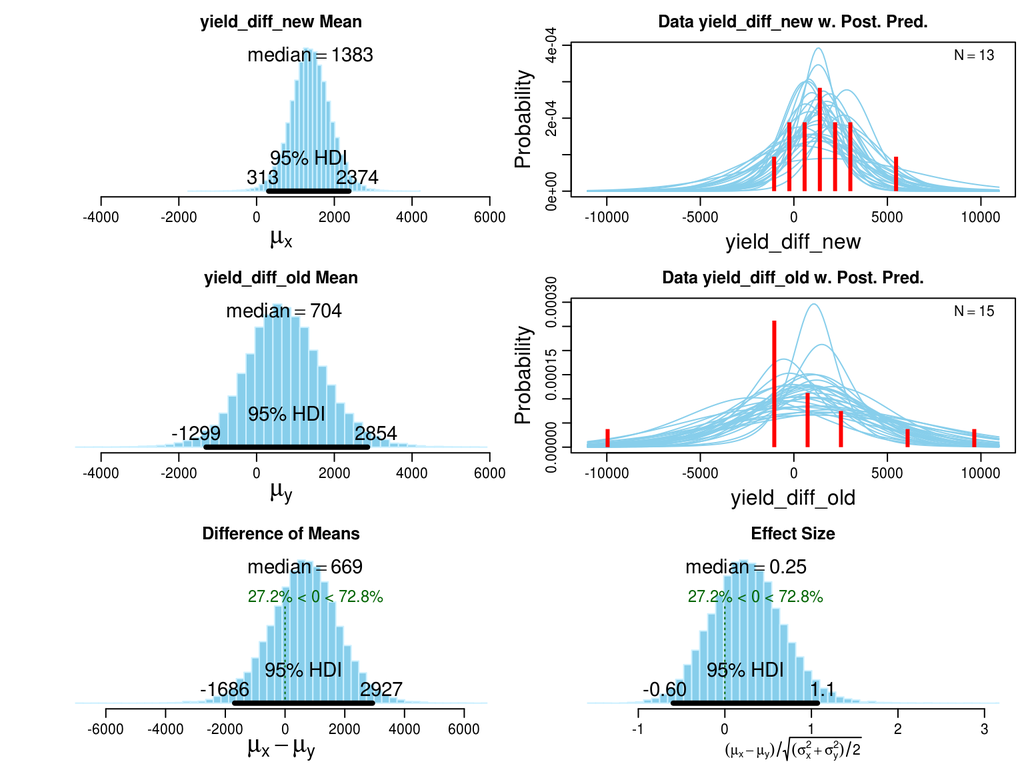

```r
fit <- bayes.t.test(yield_diff_new, yield_diff_old)
plot(fit)
```

## Bayesian alternative to binomial test

```r
binom.test(x=11, n=20, p=0.32)
```

```
##
##  Exact binomial test
##
## data:  11 and 20
## number of successes = 11, number of trials = 20, p-value = 0.05138
## alternative hypothesis: true probability of success is not equal to 0.32
## 95 percent confidence interval:
##  0.3152781 0.7694221
## sample estimates:
## probability of success
##                   0.55
```

```r
bayes.binom.test(x=11, n=20, p=0.32)
```

```
##
##  Bayesian First Aid binomial test
##
## data: 11 and 20
## number of successes = 11, number of trials = 20
## Estimated relative frequency of success:
##   0.55
## 95% credible interval:
##   0.34 0.74
## The relative frequency of success is more than 0.32 by a probability of 0.986
## and less than 0.32 by a probability of 0.014
```

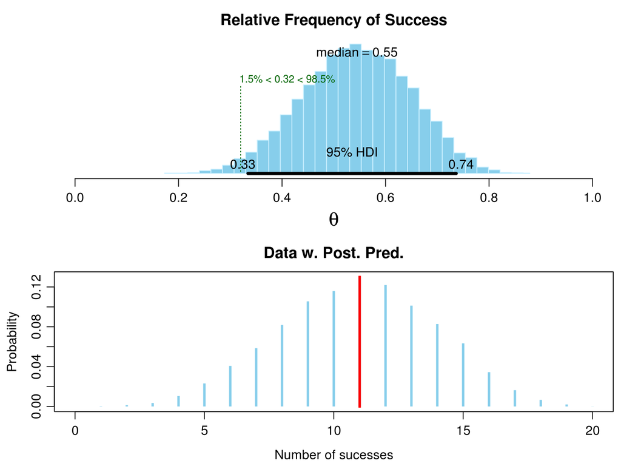

```r
fit2 <- bayes.binom.test(x=11, n=20, p=0.32)
plot(fit2)
```